# MOwNiT

## Laboratorium 1

### Analiza danych - DataFrames

- Zaawansowany pakiet do działania na tabelkach nxm danych
- Podobne do pandas DataFrames w Pythonie albo data.frame w R
- Specjalistyczne funkcje do statystyki
- W przypadku włąsnej instalacji należy zaistalować pakiet:

```
Pkg.add("DataFrames" )
```

- DataFrame to rodzaj bazy danych in-memory
- Składa się z kolumn, do których odwołujemy się używając symboli
- Każda z kolumn może przechowywać inny typ (inaczej niż w dwuwymiarowych tablicach )
- każda z kolumn jest typu Array{T,1} gdzie T jest okreslonym typem danych (np. Float64)
- strona pakietu: https://github.com/JuliaStats/DataFrames.jl
- dokumentacja najnowszej wersji: https://juliadata.github.io/DataFrames.jl/stable/index.html

```julia
# za pierwszym razem, jeśli uruchamiamy lokalnie to instalujemy
#using Pkg
#Pkg.add("DataFrames")
```

```julia
# Tworzenie DataFrame
using DataFrames
df1=DataFrame()
df1.MojaKolumna= 1:4
df1.x2= [4,pi,sqrt(2), 42]
df1.Col3= [true,false, true, false]
show(df1)
```

```
4×3 DataFrame
 Row │ MojaKolumna  x2        Col3
     │ Int64        Float64   Bool
─────┼──────────────────────────────
   1 │           1   4.0       true
   2 │           2   3.14159  false
   3 │           3   1.41421   true
   4 │           4  42.0      false
```

```julia
# ! - nie tworzy kopii, : - tworzy kopię
typeof(df1[!,2])
```

```
Vector{Float64} (alias for Array{Float64, 1})
```

```julia
typeof(df1[:,2])
```

```
Vector{Float64} (alias for Array{Float64, 1})
```

```julia
typeof(df1.Col3)
```

```
Vector{Bool} (alias for Array{Bool, 1})
```

```julia
# możemy też utworzyć DataFrame używając konstruktora
df2=DataFrame(MojaKolumna=1:10,
    Col2=[2,pi, sqrt(2), 3, 4,2,pi, sqrt(2), 3, 4],
    Col3=[true,true,false,true,false,true,true,false,true,false])
```

10×3 DataFrame

| Row | MojaKolumna Int64 | Col2 Float64 | Col3 Bool |
| --- | --- | --- | --- |
| 1 | 1 | 2.0 | true |
| 2 | 2 | 3.14159 | true |
| 3 | 3 | 1.41421 | false |
| 4 | 4 | 3.0 | true |
| 5 | 5 | 4.0 | false |
| 6 | 6 | 2.0 | true |
| 7 | 7 | 3.14159 | true |
| 8 | 8 | 1.41421 | false |
| 9 | 9 | 3.0 | true |
| 10 | 10 | 4.0 | false |

```julia
# ilosc wierszy
size(df2, 1)
```

```
10
```

```julia
#ilosc kolumn
size(df2, 2)
```

```
3
```

```julia
# można odwoływać się po indeksie
show(df2[:,2])
```

```
[2.0, 3.141592653589793, 1.4142135623730951, 3.0, 4.0, 2.0, 3.141592653589793, 1.4142135623730951, 3.0, 4.0]
```

```julia
# albo po symbolu kolumny
show(df2[!,:Col2])
```

```
[2.0, 3.141592653589793, 1.4142135623730951, 3.0, 4.0, 2.0, 3.141592653589793, 1.4142135623730951, 3.0, 4.0]
```

```julia
# wiersze lub podzbiory wierszy i kolumn uzyskujemy poprzez operator (:). Wynikiem jest nowy DataFrame
show(df2[3,:])
```

```
DataFrameRow
 Row │ MojaKolumna  Col2     Col3
     │ Int64        Float64  Bool
─────┼─────────────────────────────
   3 │           3  1.41421  false
```

```julia
# drugi i trzeci wiersz
df2[2:3, :]
```

2×3 DataFrame

| Row | MojaKolumna Int64 | Col2 Float64 | Col3 Bool |
| --- | --- | --- | --- |
| 1 | 2 | 3.14159 | true |
| 2 | 3 | 1.41421 | false |

```julia
# druga kolumna drugiego i trzeciego wiersza
df2[2:3, :Col2]
```

```
2-element Vector{Float64}:
 3.141592653589793
 1.4142135623730951
```

```julia
# druga i trzecia kolumna drugiego i trzeciego wiersza
df2[2:3,[:Col2, :Col3]]
```

2×2 DataFrame

| Row | Col2 Float64 | Col3 Bool |
| --- | --- | --- |
| 1 | 3.14159 | true |
| 2 | 1.41421 | false |

```julia
# pierwsze sześć wierszy
DataFrames.first(df2,6)
```

6×3 DataFrame

| Row | MojaKolumna Int64 | Col2 Float64 | Col3 Bool |
| --- | --- | --- | --- |
| 1 | 1 | 2.0 | true |
| 2 | 2 | 3.14159 | true |
| 3 | 3 | 1.41421 | false |
| 4 | 4 | 3.0 | true |
| 5 | 5 | 4.0 | false |
| 6 | 6 | 2.0 | true |

```julia
# ostatnie sześć wierszy
DataFrames.last(df2,6)
```

6×3 DataFrame

| Row | MojaKolumna Int64 | Col2 Float64 | Col3 Bool |
| --- | --- | --- | --- |
| 1 | 5 | 4.0 | false |
| 2 | 6 | 2.0 | true |
| 3 | 7 | 3.14159 | true |
| 4 | 8 | 1.41421 | false |
| 5 | 9 | 3.0 | true |
| 6 | 10 | 4.0 | false |

```julia
# nazwy kolumn
names(df2)
```

```
3-element Vector{String}:
 "MojaKolumna"
 "Col2"
 "Col3"
```

```julia
# typy kolumn
eltype.(eachcol(df2))
```

```
3-element Vector{DataType}:
 Int64
 Float64
 Bool
```

```julia
# podstawowe dane statystyczne o wartościach w kolumnie
describe(df2)
```

3×7 DataFrame

| Row | variable Symbol | mean Float64 | min Real | median Float64 | max Real | nmissing Int64 | eltype DataType |
| --- | --- | --- | --- | --- | --- | --- | --- |
| 1 | MojaKolumna | 5.5 | 1 | 5.5 | 10 | 0 | Int64 |
| 2 | Col2 | 2.71116 | 1.41421 | 3.0 | 4.0 | 0 | Float64 |
| 3 | Col3 | 0.6 | false | 1.0 | true | 0 | Bool |

```julia
using Statistics
mean(df2.Col2)
```

```
2.711161243192578
```

```julia
var(df2.Col2)
```

```
0.9150284373648316
```

```julia
#using Pkg
#Pkg.add("CSV")
using CSV
input="winequality.csv"
mydata=CSV.read(input, delim=";",DataFrame)
```

1599×12 DataFrame

1574 rows omitted

| Row | fixed acidity Float64 | volatile acidity Float64 | citric acid Float64 | residual sugar Float64 | chlorides Float64 | free sulfur dioxide Float64 | total sulfur dioxide Float64 | density Float64 | pH Float64 | sulphates Float64 | alcohol Float64 | quality Int64 |
| --- | --- | --- | --- | --- | --- | --- | --- | --- | --- | --- | --- | --- |
| 1 | 7.4 | 0.7 | 0.0 | 1.9 | 0.076 | 11.0 | 34.0 | 0.9978 | 3.51 | 0.56 | 9.4 | 5 |
| 2 | 7.8 | 0.88 | 0.0 | 2.6 | 0.098 | 25.0 | 67.0 | 0.9968 | 3.2 | 0.68 | 9.8 | 5 |
| 3 | 7.8 | 0.76 | 0.04 | 2.3 | 0.092 | 15.0 | 54.0 | 0.997 | 3.26 | 0.65 | 9.8 | 5 |
| 4 | 11.2 | 0.28 | 0.56 | 1.9 | 0.075 | 17.0 | 60.0 | 0.998 | 3.16 | 0.58 | 9.8 | 6 |
| 5 | 7.4 | 0.7 | 0.0 | 1.9 | 0.076 | 11.0 | 34.0 | 0.9978 | 3.51 | 0.56 | 9.4 | 5 |
| 6 | 7.4 | 0.66 | 0.0 | 1.8 | 0.075 | 13.0 | 40.0 | 0.9978 | 3.51 | 0.56 | 9.4 | 5 |
| 7 | 7.9 | 0.6 | 0.06 | 1.6 | 0.069 | 15.0 | 59.0 | 0.9964 | 3.3 | 0.46 | 9.4 | 5 |
| 8 | 7.3 | 0.65 | 0.0 | 1.2 | 0.065 | 15.0 | 21.0 | 0.9946 | 3.39 | 0.47 | 10.0 | 7 |
| 9 | 7.8 | 0.58 | 0.02 | 2.0 | 0.073 | 9.0 | 18.0 | 0.9968 | 3.36 | 0.57 | 9.5 | 7 |
| 10 | 7.5 | 0.5 | 0.36 | 6.1 | 0.071 | 17.0 | 102.0 | 0.9978 | 3.35 | 0.8 | 10.5 | 5 |
| 11 | 6.7 | 0.58 | 0.08 | 1.8 | 0.097 | 15.0 | 65.0 | 0.9959 | 3.28 | 0.54 | 9.2 | 5 |
| 12 | 7.5 | 0.5 | 0.36 | 6.1 | 0.071 | 17.0 | 102.0 | 0.9978 | 3.35 | 0.8 | 10.5 | 5 |
| 13 | 5.6 | 0.615 | 0.0 | 1.6 | 0.089 | 16.0 | 59.0 | 0.9943 | 3.58 | 0.52 | 9.9 | 5 |
| ⋮ | ⋮ | ⋮ | ⋮ | ⋮ | ⋮ | ⋮ | ⋮ | ⋮ | ⋮ | ⋮ | ⋮ | ⋮ |
| 1588 | 5.8 | 0.61 | 0.11 | 1.8 | 0.066 | 18.0 | 28.0 | 0.99483 | 3.55 | 0.66 | 10.9 | 6 |
| 1589 | 7.2 | 0.66 | 0.33 | 2.5 | 0.068 | 34.0 | 102.0 | 0.99414 | 3.27 | 0.78 | 12.8 | 6 |
| 1590 | 6.6 | 0.725 | 0.2 | 7.8 | 0.073 | 29.0 | 79.0 | 0.9977 | 3.29 | 0.54 | 9.2 | 5 |
| 1591 | 6.3 | 0.55 | 0.15 | 1.8 | 0.077 | 26.0 | 35.0 | 0.99314 | 3.32 | 0.82 | 11.6 | 6 |
| 1592 | 5.4 | 0.74 | 0.09 | 1.7 | 0.089 | 16.0 | 26.0 | 0.99402 | 3.67 | 0.56 | 11.6 | 6 |
| 1593 | 6.3 | 0.51 | 0.13 | 2.3 | 0.076 | 29.0 | 40.0 | 0.99574 | 3.42 | 0.75 | 11.0 | 6 |
| 1594 | 6.8 | 0.62 | 0.08 | 1.9 | 0.068 | 28.0 | 38.0 | 0.99651 | 3.42 | 0.82 | 9.5 | 6 |
| 1595 | 6.2 | 0.6 | 0.08 | 2.0 | 0.09 | 32.0 | 44.0 | 0.9949 | 3.45 | 0.58 | 10.5 | 5 |
| 1596 | 5.9 | 0.55 | 0.1 | 2.2 | 0.062 | 39.0 | 51.0 | 0.99512 | 3.52 | 0.76 | 11.2 | 6 |
| 1597 | 6.3 | 0.51 | 0.13 | 2.3 | 0.076 | 29.0 | 40.0 | 0.99574 | 3.42 | 0.75 | 11.0 | 6 |
| 1598 | 5.9 | 0.645 | 0.12 | 2.0 | 0.075 | 32.0 | 44.0 | 0.99547 | 3.57 | 0.71 | 10.2 | 5 |
| 1599 | 6.0 | 0.31 | 0.47 | 3.6 | 0.067 | 18.0 | 42.0 | 0.99549 | 3.39 | 0.66 | 11.0 | 6 |

```julia
describe(mydata)
```

12×7 DataFrame

| Row | variable Symbol | mean Float64 | min Real | median Float64 | max Real | nmissing Int64 | eltype DataType |
| --- | --- | --- | --- | --- | --- | --- | --- |
| 1 | fixed acidity | 8.31964 | 4.6 | 7.9 | 15.9 | 0 | Float64 |
| 2 | volatile acidity | 0.527821 | 0.12 | 0.52 | 1.58 | 0 | Float64 |
| 3 | citric acid | 0.270976 | 0.0 | 0.26 | 1.0 | 0 | Float64 |
| 4 | residual sugar | 2.53881 | 0.9 | 2.2 | 15.5 | 0 | Float64 |
| 5 | chlorides | 0.0874665 | 0.012 | 0.079 | 0.611 | 0 | Float64 |
| 6 | free sulfur dioxide | 15.8749 | 1.0 | 14.0 | 72.0 | 0 | Float64 |
| 7 | total sulfur dioxide | 46.4678 | 6.0 | 38.0 | 289.0 | 0 | Float64 |
| 8 | density | 0.996747 | 0.99007 | 0.99675 | 1.00369 | 0 | Float64 |
| 9 | pH | 3.31111 | 2.74 | 3.31 | 4.01 | 0 | Float64 |
| 10 | sulphates | 0.658149 | 0.33 | 0.62 | 2.0 | 0 | Float64 |
| 11 | alcohol | 10.423 | 8.4 | 10.2 | 14.9 | 0 | Float64 |
| 12 | quality | 5.63602 | 3 | 6.0 | 8 | 0 | Int64 |

```julia
typeof(mydata)
```

```
DataFrame
```

```julia
size(mydata)
```

```
(1599, 12)
```

```julia
# Dzielenie DataFrame na podgrupy i działania na nich

# Split -Apply - Combine

#https://dataframes.juliadata.org/stable/man/split_apply_combine/

# rozdzielanie na podgrupy po jakości wina (quality)
# Split

wine_grouped=groupby(mydata, :quality)
```

**GroupedDataFrame with 6 groups based on key: quality**

First Group (10 rows): quality = 3

| Row | fixed acidity Float64 | volatile acidity Float64 | citric acid Float64 | residual sugar Float64 | chlorides Float64 | free sulfur dioxide Float64 | total sulfur dioxide Float64 | density Float64 | pH Float64 | sulphates Float64 | alcohol Float64 | quality Int64 |
| --- | --- | --- | --- | --- | --- | --- | --- | --- | --- | --- | --- | --- |
| 1 | 11.6 | 0.58 | 0.66 | 2.2 | 0.074 | 10.0 | 47.0 | 1.0008 | 3.25 | 0.57 | 9.0 | 3 |
| 2 | 10.4 | 0.61 | 0.49 | 2.1 | 0.2 | 5.0 | 16.0 | 0.9994 | 3.16 | 0.63 | 8.4 | 3 |
| 3 | 7.4 | 1.185 | 0.0 | 4.25 | 0.097 | 5.0 | 14.0 | 0.9966 | 3.63 | 0.54 | 10.7 | 3 |
| 4 | 10.4 | 0.44 | 0.42 | 1.5 | 0.145 | 34.0 | 48.0 | 0.99832 | 3.38 | 0.86 | 9.9 | 3 |
| 5 | 8.3 | 1.02 | 0.02 | 3.4 | 0.084 | 6.0 | 11.0 | 0.99892 | 3.48 | 0.49 | 11.0 | 3 |
| 6 | 7.6 | 1.58 | 0.0 | 2.1 | 0.137 | 5.0 | 9.0 | 0.99476 | 3.5 | 0.4 | 10.9 | 3 |
| 7 | 6.8 | 0.815 | 0.0 | 1.2 | 0.267 | 16.0 | 29.0 | 0.99471 | 3.32 | 0.51 | 9.8 | 3 |
| 8 | 7.3 | 0.98 | 0.05 | 2.1 | 0.061 | 20.0 | 49.0 | 0.99705 | 3.31 | 0.55 | 9.7 | 3 |
| 9 | 7.1 | 0.875 | 0.05 | 5.7 | 0.082 | 3.0 | 14.0 | 0.99808 | 3.4 | 0.52 | 10.2 | 3 |
| 10 | 6.7 | 0.76 | 0.02 | 1.8 | 0.078 | 6.0 | 12.0 | 0.996 | 3.55 | 0.63 | 9.95 | 3 |

⋮

Last Group (18 rows): quality = 8

| Row | fixed acidity Float64 | volatile acidity Float64 | citric acid Float64 | residual sugar Float64 | chlorides Float64 | free sulfur dioxide Float64 | total sulfur dioxide Float64 | density Float64 | pH Float64 | sulphates Float64 | alcohol Float64 | quality Int64 |
| --- | --- | --- | --- | --- | --- | --- | --- | --- | --- | --- | --- | --- |
| 1 | 7.9 | 0.35 | 0.46 | 3.6 | 0.078 | 15.0 | 37.0 | 0.9973 | 3.35 | 0.86 | 12.8 | 8 |
| 2 | 10.3 | 0.32 | 0.45 | 6.4 | 0.073 | 5.0 | 13.0 | 0.9976 | 3.23 | 0.82 | 12.6 | 8 |
| 3 | 5.6 | 0.85 | 0.05 | 1.4 | 0.045 | 12.0 | 88.0 | 0.9924 | 3.56 | 0.82 | 12.9 | 8 |
| 4 | 12.6 | 0.31 | 0.72 | 2.2 | 0.072 | 6.0 | 29.0 | 0.9987 | 2.88 | 0.82 | 9.8 | 8 |
| 5 | 11.3 | 0.62 | 0.67 | 5.2 | 0.086 | 6.0 | 19.0 | 0.9988 | 3.22 | 0.69 | 13.4 | 8 |
| 6 | 9.4 | 0.3 | 0.56 | 2.8 | 0.08 | 6.0 | 17.0 | 0.9964 | 3.15 | 0.92 | 11.7 | 8 |
| 7 | 10.7 | 0.35 | 0.53 | 2.6 | 0.07 | 5.0 | 16.0 | 0.9972 | 3.15 | 0.65 | 11.0 | 8 |
| 8 | 10.7 | 0.35 | 0.53 | 2.6 | 0.07 | 5.0 | 16.0 | 0.9972 | 3.15 | 0.65 | 11.0 | 8 |
| 9 | 5.0 | 0.42 | 0.24 | 2.0 | 0.06 | 19.0 | 50.0 | 0.9917 | 3.72 | 0.74 | 14.0 | 8 |
| 10 | 7.8 | 0.57 | 0.09 | 2.3 | 0.065 | 34.0 | 45.0 | 0.99417 | 3.46 | 0.74 | 12.7 | 8 |
| 11 | 9.1 | 0.4 | 0.5 | 1.8 | 0.071 | 7.0 | 16.0 | 0.99462 | 3.21 | 0.69 | 12.5 | 8 |
| 12 | 10.0 | 0.26 | 0.54 | 1.9 | 0.083 | 42.0 | 74.0 | 0.99451 | 2.98 | 0.63 | 11.8 | 8 |
| 13 | 7.9 | 0.54 | 0.34 | 2.5 | 0.076 | 8.0 | 17.0 | 0.99235 | 3.2 | 0.72 | 13.1 | 8 |
| 14 | 8.6 | 0.42 | 0.39 | 1.8 | 0.068 | 6.0 | 12.0 | 0.99516 | 3.35 | 0.69 | 11.7 | 8 |
| 15 | 5.5 | 0.49 | 0.03 | 1.8 | 0.044 | 28.0 | 87.0 | 0.9908 | 3.5 | 0.82 | 14.0 | 8 |
| 16 | 7.2 | 0.33 | 0.33 | 1.7 | 0.061 | 3.0 | 13.0 | 0.996 | 3.23 | 1.1 | 10.0 | 8 |
| 17 | 7.2 | 0.38 | 0.31 | 2.0 | 0.056 | 15.0 | 29.0 | 0.99472 | 3.23 | 0.76 | 11.3 | 8 |
| 18 | 7.4 | 0.36 | 0.3 | 1.8 | 0.074 | 17.0 | 24.0 | 0.99419 | 3.24 | 0.7 | 11.4 | 8 |

```julia
# podsumowanie ile jest win w każdej grupie
combine(wine_grouped, nrow)
```

6×2 DataFrame

| Row | quality Int64 | nrow Int64 |
| --- | --- | --- |
| 1 | 3 | 10 |
| 2 | 4 | 53 |
| 3 | 5 | 681 |
| 4 | 6 | 638 |
| 5 | 7 | 199 |
| 6 | 8 | 18 |

```julia
combine(wine_grouped, "fixed acidity" => mean)
```

6×2 DataFrame

| Row | quality Int64 | fixed acidity_mean Float64 |
| --- | --- | --- |
| 1 | 3 | 8.36 |
| 2 | 4 | 7.77925 |
| 3 | 5 | 8.16725 |
| 4 | 6 | 8.34718 |
| 5 | 7 | 8.87236 |
| 6 | 8 | 8.56667 |

```julia
# zliczenie liczby win o danej jakości i zawartości alkoholu, posortowane
wine_grouped2=sort(combine(groupby(mydata, [:quality,:alcohol]),nrow=> :liczba), [:quality,:alcohol])
```

190×3 DataFrame

165 rows omitted

| Row | quality Int64 | alcohol Float64 | liczba Int64 |
| --- | --- | --- | --- |
| 1 | 3 | 8.4 | 1 |
| 2 | 3 | 9.0 | 1 |
| 3 | 3 | 9.7 | 1 |
| 4 | 3 | 9.8 | 1 |
| 5 | 3 | 9.9 | 1 |
| 6 | 3 | 9.95 | 1 |
| 7 | 3 | 10.2 | 1 |
| 8 | 3 | 10.7 | 1 |
| 9 | 3 | 10.9 | 1 |
| 10 | 3 | 11.0 | 1 |
| 11 | 4 | 9.0 | 2 |
| 12 | 4 | 9.05 | 1 |
| 13 | 4 | 9.1 | 2 |
| ⋮ | ⋮ | ⋮ | ⋮ |
| 179 | 8 | 11.3 | 1 |
| 180 | 8 | 11.4 | 1 |
| 181 | 8 | 11.7 | 2 |
| 182 | 8 | 11.8 | 1 |
| 183 | 8 | 12.5 | 1 |
| 184 | 8 | 12.6 | 1 |
| 185 | 8 | 12.7 | 1 |
| 186 | 8 | 12.8 | 1 |
| 187 | 8 | 12.9 | 1 |
| 188 | 8 | 13.1 | 1 |
| 189 | 8 | 13.4 | 1 |
| 190 | 8 | 14.0 | 2 |

```julia
# zapis do pliku
CSV.write("dataframe1.csv", wine_grouped2)
```

```
"dataframe1.csv"
```

### Graficzna reprezentacja DataFrames

```julia
using DataFrames
df = DataFrame(a = 1:10, b = map(x->2x,(1:10)), c = map(x->log(x),(1:10)), d=rand(10), e=map(x->x%2,(1:10)))
```

10×5 DataFrame

| Row | a Int64 | b Int64 | c Float64 | d Float64 | e Int64 |
| --- | --- | --- | --- | --- | --- |
| 1 | 1 | 2 | 0.0 | 0.162046 | 1 |
| 2 | 2 | 4 | 0.693147 | 0.971315 | 0 |
| 3 | 3 | 6 | 1.09861 | 0.507261 | 1 |
| 4 | 4 | 8 | 1.38629 | 0.649081 | 0 |
| 5 | 5 | 10 | 1.60944 | 0.59623 | 1 |
| 6 | 6 | 12 | 1.79176 | 0.568477 | 0 |
| 7 | 7 | 14 | 1.94591 | 0.258198 | 1 |
| 8 | 8 | 16 | 2.07944 | 0.762426 | 0 |
| 9 | 9 | 18 | 2.19722 | 0.0718669 | 1 |
| 10 | 10 | 20 | 2.30259 | 0.516336 | 0 |

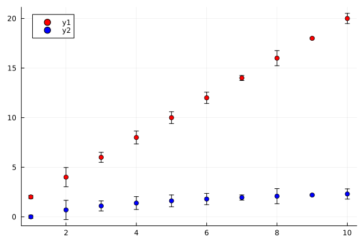

```julia
# Mozna odwolywac sie bezposrednio do kolumn w poniższy sposób (gdyz sa typu jednowymiarowych tablic
# Array{T,1})
#Pkg.add("Plots")
using Plots
scatter(df.a, [df.b, df.c], colour = [:red :blue], yerr=df.d)
```

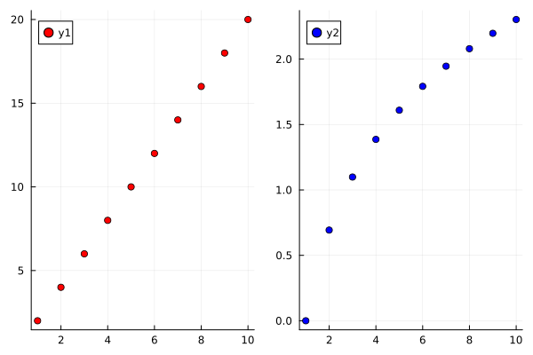

```julia
# użycie opcji layout
scatter(df.a, [df.b, df.c],  colour = [:red :blue ], layout=2)
```

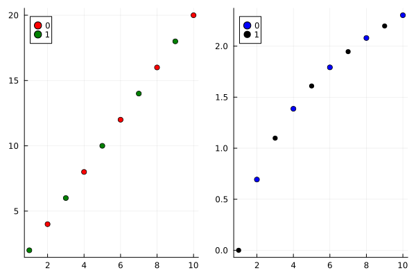

```julia
# użycie opcji layout i grup
scatter(df.a, [df.b, df.c], group=df.e,  colour = [:red :blue :green :black], layout=2)
```

Uwaga: Ze względu na specyfikę języka Julia pomiar czasu wykonania należy brać pod uwagę dopiero od drugiego wywołania danej funkcji (za pierwszym razem mierzymy również czas kompilacji)

Makro @time - zwraca wartość funkcji i wypisuje czas jej trwania. Makro @elapsed zwraca czas trwania (może być wygodniejsze w użyciu). Warto też oglądnąć działanie makr @timev, @timed, i @allocated

https://docs.julialang.org/en/v1/base/base/#Base.@time

Rand(10) - wylosuj 10-elementową tablicę Float64 z przedziału [0,1)

https://docs.julialang.org/en/v1/stdlib/Random/#Base.rand

### Zadanie

- Założenie: macierz A - kwadratowa rozmiar n x n; wektory x, y rozmiar n
- Napisać programy w języku Julia do obliczania: **uogólnionego** iloczynu skalarnego dot(x, **A**, y) wektorów z użyciem [LinearAlgebra.dot](https://docs.julialang.org/en/v1/stdlib/LinearAlgebra/#LinearAlgebra.dot-Tuple{Any,%20Any,%20Any}) oraz mnożenia macierzy kwadratowej przez wektor (czyli obliczania A*x) z użyciem [operatora *](https://docs.julialang.org/en/v1/stdlib/LinearAlgebra/#Elementary-operations-1).
- Uruchomić i zmierzyć czasy działania obydwu funkcji - każdej dla różnych rozmiarów wektorów n. Uwaga: rozmiary dobrać tak, żeby nie zużyć zbyt wiele pamięci, a jednocześnie uzyskać niezerowe wyniki czasowe (wielkości będą zależeć od mocy sprzętu - można próbować testować w okolicach n=1000). Dokonać 10 pomiarów dla każdego rozmiaru wektora.
- Czasy działania powinny być zapisywane do **jednego** pliku CSV. Należy zaplanować odpowiednią strukturę kolumn takiego pliku.
- Wczytać dane z w/w pliku do **jednego** DataFrame w języku Julia.
- Korzystająć z mechanizmów DataFrame w języku Julia obliczyć średnią i odchylenie standardowe, w taki sposób, aby narysować wykresy średnich czasów obliczenia operacji w zależności od rozmiaru wektora. Dodać słupki błędów do obydwu wykresów uzyskanych z obliczenia odchylenia standardowego.
- Proszę poukładac wykresy w tabelkę za pomocą opcji layouts: https://docs.juliaplots.org/latest/layouts/#Simple-Layouts-1.
- Należy zadbać o staranne podpisanie osi i wykresów.